# Construction delay: a quantitative analysis - ScienceDirect

## [International Journal of Project Management](https://www.sciencedirect.com/journal/international-journal-of-project-management)

[Volume 18, Issue 1](https://www.sciencedirect.com/journal/international-journal-of-project-management/vol/18/issue/1), February 2000, Pages 51-59

# Construction delay: a quantitative analysis

https://doi.org/10.1016/S0263-7863(98)00060-X[Get rights and content](https://s100.copyright.com/AppDispatchServlet?publisherName=ELS&contentID=S026378639800060X&orderBeanReset=true)

Abstract

Avoiding construction claims and disputes requires an understanding of the contractual terms and causes of claims. The dual underlying theme of this paper is to investigate the causes of delays on 130 public projects in Jordan and to aid construction managers in establishing adequate evaluation prior to the contract award using quantitative data. Projects investigated in this study included residential, office and administration buildings, school buildings, medical centers and communication facilities. Results of this study indicates the main causes of delay in construction of public projects relate to designers, user changes, weather, site conditions, late deliveries, economic conditions and increase in quantity. The presence of these factors have an impact on the successful completion of the projects at the time contractually specified. The findings suggest that special attention to factors identified in this study will help industry practitioners in minimising the risk of contract disputes.

## Keywords

Construction management

Project planning

Construction delay

Dispute

## 1. Introduction

A vital section specified in the construction contract is the performance period or time of project execution, which is established prior to bidding. The successful execution of construction projects and keeping them within estimated cost and the prescribed schedules depend on a methodology that requires sound engineering judgment.[1] The construction sector is one of the vital sectors in the development process of Jordan. The government contributes to the development of the construction industry in several ways. However, there are limitations and even draw backs to these efforts. The time required to complete construction of public projects is frequently greater than the time specified in the contract. These `overruns' or time extensions are granted for many reasons, such as designer changes or errors, user changes, weather and late deliveries. Current construction projects are complex efforts requiring the support of the design and construction profession. Therefore, a realistic time for project execution will decrease the possibility of disputes between state agency and the contractors.

### 1.1. Previous work

A great deal of information concerned with project delay and overruns may be found in the literature. The increased interest in construction overruns is due, in part, to efforts by the government to reduce construction delays. There has been a considerable and continued interest in the effect of construction delays. The information available is diverse and widespread. Many construction management books[2], [3], [4], [5], [6] have minimum coverage on construction delays. Al-Momani[7] describe the various elements of cost upon individual public projects but does not deal specifically with construction delays.

Assaf and Al-khalil[8] outline the main causes of delay in large building projects and their relative importance. They found that 56 causes of delay exist in Saudi construction projects. According to the contractors surveyed the most important delay factors were preparation and approval of shop drawings, delays in contractor's progress, payment by owners and design changes. The architects and engineers view were cash problems during construction, the relationship between subcontractors and the slow decision making process of the owner. The owners agree that the design errors, labor shortages and inadequate labor skills are important delay factors. Hancher and Rowings,[1] for example, provide a concise summary of the methodologies used by transportation agencies to establish the contract duration used for highway construction projects, and also provides a schedule guide for field engineers during construction. Similarly, Chalabi and Camp[10] conducted a review on project delays in developing countries during planning and construction stages. In their study they found that the delay and cost overruns of construction projects are dependent entirely on the very early stages of the project. Fereig and Qaddumi[11] in their study on the construction experience of the Arabian Gulf demonstrate the various components of the planning, controlling and productivity on construction delay. Their primary purpose is to alert the reader to the deviation from the project plans.

Wilson[9] examined the role of the owner and architect/engineer's roles in the prevention and resolution of construction claims. Wilson also summarised the causes of construction claims which include: extra work, project delays and acceleration, lack of management, limited site access and change in work schedule.

Despite the necessity for such research, little work has been described in the literature concerning public projects, specially in Jordan. The previously proposed factors contributing to construction delay were frequently observed in public projects. The actual frequency and magnitude of these factors is not known, which has proven to be a serious and very expensive problem to Jordan's construction industry.

### 1.2. Research design and objectives

The objective of this study is to determine the causes and the level of time extension of public projects and to aid construction managers in establishing adequate evaluation prior to the contract award using quantitative data. The key task is to design research so that the information obtained permits the assessment of their impact. Therefore, the best approach to assessing these potentials is to adopt randomly selected samples. The sampling population was established by selecting 130 public projects constructed in different regions of Jordan during the period of 1990–97. The data was found in contract files of several state agencies. Data collected were of 5 kinds of public projects: residential houses of public figures, office and administrative buildings, school buildings, medical centers and communication facilities. The performance and construction of these projects were recognised as being unsatisfactory to many officials, and assented to the study in order to have hard evidence as to the nature of the problems. This study will summarise the results of this research based on actual construction times experienced by public projects. The data collection was to investigate the reasons related to construction delay and overruns:

- •

  Planned duration of contract;
- •

  Actual completion date;
- •

  Design changes;
- •

  Disputes;
- •

  Notification of extra work;
- •

  Date of notice to proceed;
- •

  Delay encountered during construction;
- •

  Conflict of the drawings and specifications;
- •

  Time extensions;
- •

  Late delivery of materials and equipment.

## 2. Discussions

The data were entered into Excel 5 where all analysis and diagrams were developed. The first step was to explore the parameters as to causes of delay. To this effect, parameters were defined and constructed in Table 1 for public projects. These restrictions create a sample with 130 projects. The table provide frequencies for each parameter in five different construction categories. Many projects were delayed for many reasons. All extensions to the planned schedule were considered as delays. The major causes identified were: poor design, change orders, weather, site conditions, late delivery, economic conditions and increase in quantity. A breakdown of the projects by these parameters is graphically illustrated in Fig. 1. The overall delays were in 106 out of 130 (81.5%) projects. The main causes for delays were poor design in 32 projects (24.6%), while the second cause was the change orders in 20 projects (15.4%). The site conditions and the economic conditions were the least cause of delay and were found in 8 projects.

Table 1. Summary of project information

| Classification | Poor design | Change orders | Weather | Site condition | Late delivery | Economic condition | Increase in quantity | No delay | Total |
| --- | --- | --- | --- | --- | --- | --- | --- | --- | --- |
| House | 4 | 1 | 3 | 1 | 0 | 0 | 2 | 3 | 14 |
| Office | 8 | 5 | 4 | 2 | 1 | 4 | 5 | 5 | 34 |
| School | 10 | 8 | 6 | 5 | 4 | 2 | 3 | 14 | 52 |
| Medical centers | 6 | 4 | 2 | 0 | 3 | 2 | 1 | 2 | 20 |
| Communication facilities | 4 | 2 | 1 | 0 | 2 | 0 | 1 | 0 | 10 |
| Total | 32 | 20 | 16 | 8 | 10 | 8 | 12 | 24 | 130 |

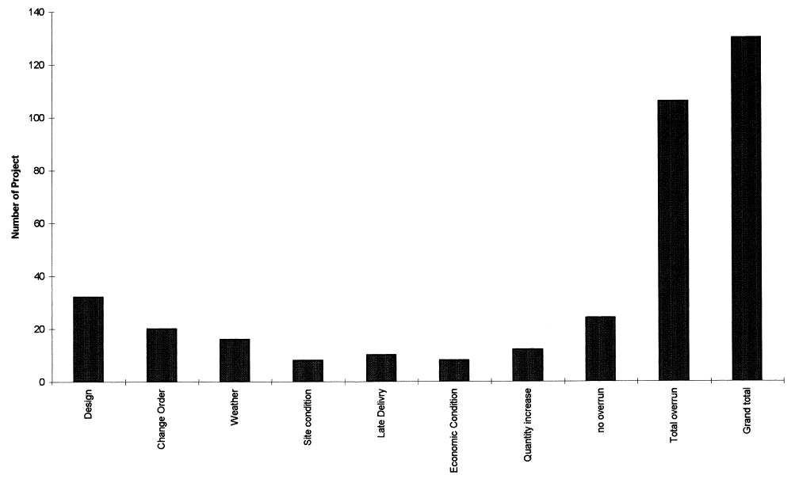

1. [Download : Download full-size image](https://ars.els-cdn.com/content/image/1-s2.0-S026378639800060X-gr1.gif)

Fig. 1. Causes of delay.

### 2.1. Planned and actual duration

Table 2. Descriptive statistics of the public projects

[output not shown]

A mathematical structure was studied by different functions that fits the data, which indicated that the simple linear regression appears to be appropriate for this type of problem. The specification of our model is determined by one independent variable which significantly explained variations in the response variable. Correlation coefficients were used for screening the variables. Several statistical tests were conducted. Each of these was performed at 99% confidence level. It was assumed that both the actual and planned times distributions were normal and independently distributed.

## 3. Tests and results

Simple linear regression develops an equation that describes the relationship between two variables. In this case the equation takes the form of:$Y=β0+β1X+ε$

In this model *Y* is the dependent variable, the parameters, *β*<sub>0</sub> and *β*<sub>1</sub> are the coefficients which are unknown and are to be estimated. *X* is the independent variable, and *ε* is a random error which is the amount of variation in *Y* not accounted for by the linear relationship. The theoretical models are derived and explained in the following.

For a comparison of the actual and planned time distribution, the equation developed for overall public projects is:(1)$Y=82.87+1.0016x$$R2=0.64D.W.=1.58 R=0.80 S.E.=102.8 F−value=231.25$

The correlation coefficient for this relationship is 0.80 indicating that the distribution of planned time mirrors the actual time with a high degree of accuracy. The calculated F is 231.25, the higher absolute value of the F-statistics reported may reflect the observation that are powerful predictors of the measured data. Therefore, true linearity exists in the developed model.

Comparing sample means to test the agreement between the two distribution was employed. In this case the *t*-statistic is 9.28 which is much larger than *t*-value of 1.97, giving further proof of the agreement between the two distributions. The general model is valuable in that it provides a universal model of phenomena and would primarily be of interest to construction officials. The predictive equation has been developed as an aggregate model for actual construction time of a public projects.

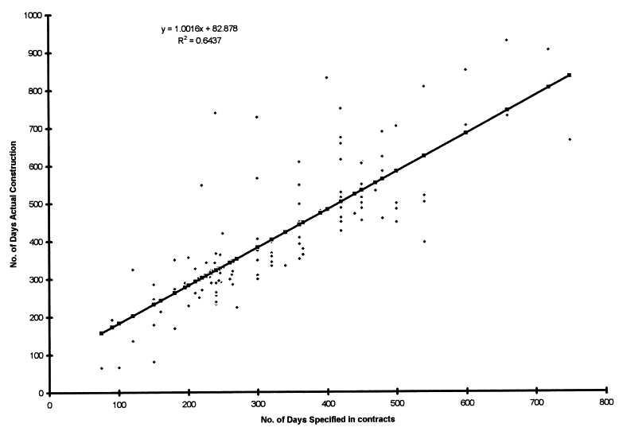

1. [Download : Download full-size image](https://ars.els-cdn.com/content/image/1-s2.0-S026378639800060X-gr2.gif)

Fig. 2. Scatter plot of actual time *Y* versus planned time *X* for general model of public projects.

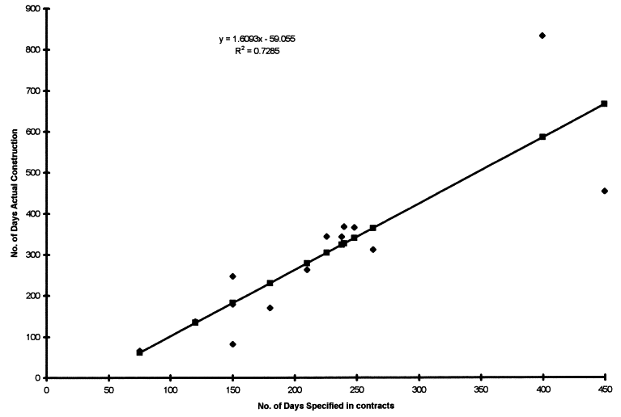

1. [Download : Download full-size image](https://ars.els-cdn.com/content/image/1-s2.0-S026378639800060X-gr3.gif)

Fig. 3. Scatter plot of actual time versus planned time of the housing model.

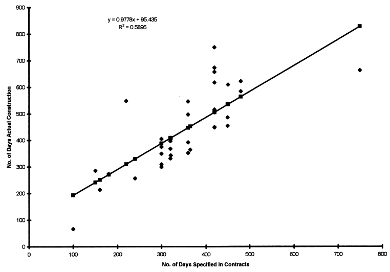

1. [Download : Download full-size image](https://ars.els-cdn.com/content/image/1-s2.0-S026378639800060X-gr4.gif)

Fig. 4. Scatter plot of actual time versus planned time of the office building model.

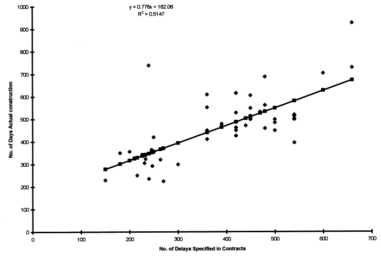

1. [Download : Download full-size image](https://ars.els-cdn.com/content/image/1-s2.0-S026378639800060X-gr5.gif)

Fig. 5. Scatter plot of actual time versus planned time of the school buildings model.

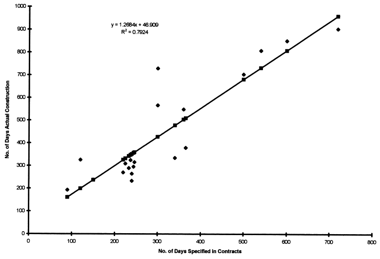

1. [Download : Download full-size image](https://ars.els-cdn.com/content/image/1-s2.0-S026378639800060X-gr6.gif)

Fig. 6. Scatter plot of actual time versus planned time of the medical centers model.

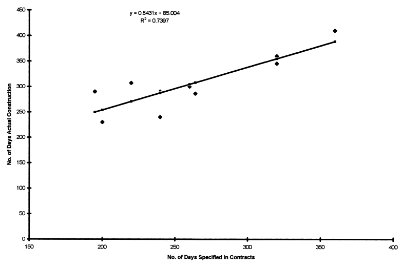

1. [Download : Download full-size image](https://ars.els-cdn.com/content/image/1-s2.0-S026378639800060X-gr7.gif)

Fig. 7. Scatter plot of actual time versus planned time of the communication facilities model.

### 3.2. Office and administration building

(3)$Y=95.4+0.97X$$R=0.76 R2=0.59S.E.=99.49 F−value=45.94$

### 3.3. School projects

(4)$Y=162.05+0.77X$$R=0.71 R2=0.51S.E.=99.36 F−value=51.97$

### 3.4. Medical centers

(5)$Y=46.9+1.3X$$R=0.89 R2=0.79S.E.=108.4 F−value=68.71$

### 3.5. Communication facilities

(6)$Y=85+0.84X$$R=0.86 R2=074S.E.=29.27 F−value=22.73$

## 4. Limitation and suggestion for further research

While this study is among the first to provide a full test of cause and determinants of construction delay, it is not without limitations. Several shortcomings in the data can be identified such as the actual cost of construction and construction experience of the contractors. The inclusion of the construction experience of the contractors as a predictor within the model underlines the importance of this extension of the analysis into the internal information of the firms. But this factor can be introduced only when the focus of study is moved from the construction industry to the construction firms. Such change of focus is not without difficulties. The collection of the company specific data is costly compared with that of publicly available data. However, the quality of future studies concerning company specific data and managerial perceptions are largely dependent on the nature of the data that is available for analysis. The future emphasis should be placed on the collection of the appropriate information and this will be the subject of an additional paper.

Projects investigated in this study exhibit a delay. In practice, this phenomena is expected to continue unless management actions are taken to control these causes within the planned element of the design and construction works. Thus good practice in planning, coordination, and the change of the control procedures of the public institutions needs to be recognised and the implications understood. The model still appears tenable, then it may be applied broadly for guidance and for planning further work and will prove beneficial in future projects.

## 5. Conclusion

Construction delay and overrun is a critical function in construction of public projects. It has been of great interest to construction researchers but has not been well understood in the case of public building projects. A survey of 130 projects indicated that poor design and negligence of the owner, change orders, weather condition, site condition, late delivery, economic conditions, and increase in quantities are the main causes of delay. In line with the reviewed research, the present investigation provides confirmation of the effect of defined parameters on construction delays.

Practically oriented research is vital for proper management of construction projects. Reliable prediction of construction duration, and then controlling cost within budget is widely used in decision making and is an essential part of successful management. To test this hypothesis, a simple linear model was used to estimate the relationship between the actual and planned time. The major implication of the foregoing have important ramifications for understanding the actual time of public projects. This has been repeatedly stated to the outstanding need of construction in Jordan. The relations obtained have the advantage of relying upon the statistical treatment of real data and could without doubt be improved by considering a larger sample of projects. The researcher believes that the arguments and findings presented in this study provide a good guidance for managerial intervention, and provide some guidelines and actionable information that managers can utilize to manage their projects.

## References

1. [1]

   D.E. Hancher, J.E. Rowings

   Setting highway construction contract duration

   Journal of the Construction Division, ASCE, 107 (2) (1981), pp. 169-179

   [CrossRef](https://doi.org/10.1061/jcceaz.0000953)[View in Scopus](https://www.scopus.com/inward/record.url?eid=2-s2.0-0019581418&partnerID=10&rel=R3.0.0)[Google Scholar](https://scholar.google.com/scholar_lookup?title=Setting%20highway%20construction%20contract%20duration&publication_year=1981&author=D.E.%20Hancher&author=J.E.%20Rowings)
2. [2]

   D.S. Barrie, B.C. Paulson

   Professional Construction Management, McGraw-Hill, Berkshire, England (1992)

   [Google Scholar](https://scholar.google.com/scholar_lookup?title=Professional%20Construction%20Management&publication_year=1992&author=D.S.%20Barrie&author=B.C.%20Paulson)
3. [3]

   D.W. Halpin, R.W. Woodhead

   Construction Management, John Wiley, New York (1980)

   [Google Scholar](https://scholar.google.com/scholar_lookup?title=Construction%20Management&publication_year=1980&author=D.W.%20Halpin&author=R.W.%20Woodhead)
4. [4]

   F. Harries, R. McCaffer

   Modern Construction Management, Blackwell Science, London, England (1995)

   [Google Scholar](https://scholar.google.com/scholar_lookup?title=Modern%20Construction%20Management&publication_year=1995&author=F.%20Harries&author=R.%20McCaffer)
5. [5]

   R. Oxley, J. Poskit

   Management Techniques Applied to Construction Industry, Blackwell Science, London (1996)

   [Google Scholar](https://scholar.google.com/scholar_lookup?title=Management%20Techniques%20Applied%20to%20Construction%20Industry&publication_year=1996&author=R.%20Oxley&author=J.%20Poskit)
6. [6]

   R. Filcher

   Principles of Construction Management, McGraw-Hill, Berkshire, England (1992)

   [Google Scholar](https://scholar.google.com/scholar_lookup?title=Principles%20of%20Construction%20Management&publication_year=1992&author=R.%20Filcher)
7. [7]

   A. Al-Momani

   Construction cost prediction for public school building in Jordan

   Construction Management and Economics, 14 (1996), pp. 311-317

   [View in Scopus](https://www.scopus.com/inward/record.url?eid=2-s2.0-0038924372&partnerID=10&rel=R3.0.0)[Google Scholar](https://scholar.google.com/scholar_lookup?title=Construction%20cost%20prediction%20for%20public%20school%20building%20in%20Jordan&publication_year=1996&author=A.%20Al-Momani)
8. [8]

   S.A. Assaf, M. Alkhalil, M. Al-Hazmi

   Causes of delay in large building construction projects

   Journal of Management in Engineering, ASCE, 11 (2) (1995), pp. 45-50

   [View in Scopus](https://www.scopus.com/inward/record.url?eid=2-s2.0-84927635730&partnerID=10&rel=R3.0.0)[Google Scholar](https://scholar.google.com/scholar_lookup?title=Causes%20of%20delay%20in%20large%20building%20construction%20projects&publication_year=1995&author=S.A.%20Assaf&author=M.%20Alkhalil&author=M.%20Al-Hazmi)
9. [9]

   R.L. Wilson

   Prevention and resolution of construction claims

   Journal of Construction Division, 108 (CO3) (1982), pp. 390-405

   [CrossRef](https://doi.org/10.1061/jcceaz.0001052)[View in Scopus](https://www.scopus.com/inward/record.url?eid=2-s2.0-0020180014&partnerID=10&rel=R3.0.0)[Google Scholar](https://scholar.google.com/scholar_lookup?title=Prevention%20and%20resolution%20of%20construction%20claims&publication_year=1982&author=R.L.%20Wilson)
10. [10]

    F.A. Chalabi, D. Camp

    Causes of delay and overruns of construction projects in developing countries

    CIB Proc., W-65, 2 (1984), pp. 273-734

    [Google Scholar](https://scholar.google.com/scholar_lookup?title=Causes%20of%20delay%20and%20overruns%20of%20construction%20projects%20in%20developing%20countries&publication_year=1984&author=F.A.%20Chalabi&author=D.%20Camp)
11. [11]

    S. Fereig, N. Qaddumi

    Construction problems—Arabian Gulf experience

    CIB Proc., W-65, 2 (1984), pp. 753-756

    [View in Scopus](https://www.scopus.com/inward/record.url?eid=2-s2.0-0021603205&partnerID=10&rel=R3.0.0)[Google Scholar](https://scholar.google.com/scholar_lookup?title=Construction%20problemsArabian%20Gulf%20experience&publication_year=1984&author=S.%20Fereig&author=N.%20Qaddumi)

- 2023, Ain Shams Engineering Journal

- 2023, Expert Systems with Applications

- 2023, Materials Today: Proceedings

- 2022, Ain Shams Engineering Journal

- 2022, Advanced Engineering Informatics

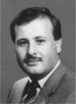

**Dr. Ayman H. Al-Momani** is an associate professor of civil engineering at Mu'tah University, Jordan. He is also vice dean of engineering and head of chemical engineering department. He served as a chairman and head of the civil engineering department for many years, and he is in charge of the construction engineering and management program, where he contributed to and developed postgraduate and undergraduate courses in construction management. He has written widely in the field and taught courses at Mu'tah University, University of Jordan, and University of Applied sciences in construction planning and scheduling, construction cost estimating, construction management, construction methods and equipment, quality control in construction, engineering economy and operation research. He received a BS in civil engineering from Leningrad university, MS in construction management from Oklahoma University, MS in industrial engineering from Central State University, and a Ph.D. from Oklahoma State University, USA. He is a member of national and international associations.

[View Abstract](https://www.sciencedirect.com/science/article/abs/pii/S026378639800060X)

Copyright © 1999 Elsevier Science Ltd and IPMA. All rights reserved.

  Pier Luigi Guida, Giovanni Sacco

  [View PDF](https://www.sciencedirect.com/science/article/pii/S0360835218306491/pdfft?md5=9c7dd8befb45ec43dd36fd3050265581&pid=1-s2.0-S0360835218306491-main.pdf)

  Long Chen, …, Daguang Han

  [View PDF](https://www.sciencedirect.com/science/article/pii/S0957417422018280/pdfft?md5=abd4cd8ce049f0e43aafc3e1348e80d6&pid=1-s2.0-S0957417422018280-main.pdf)

  Rhishikesh Thakare, …, Yazen Alnouti

  [View PDF](https://www.sciencedirect.com/science/article/pii/S073170851630334X/pdfft?md5=85013e97ac46ff6d37aac16ae5f36582&pid=1-s2.0-S073170851630334X-main.pdf)

Captures

Social Media

- Shares, Likes & Comments: 1

View details